*This notebook contains material from cbe61622; content is available [on Github](https://github.com/jckantor/cbe61622.git).*

< [10.0 Projects](https://jckantor.github.io/cbe61622/10.00-Projects.html) | Contents | [A.0 Python Source Library](https://jckantor.github.io/cbe61622/A.00-Appendices.html) >

# 10.10 Particle Labeling

The goal of this notebook is to develop a python class for the purpose of counting and labeling flourescent particles captured in images from a prototype for a low-cost medical diagnostic device.

## 10.10.1 Developing a Procedure

### 10.10.1.1 Imports

We track overall code dependencies by consolidating imports into this cell.

- [matplotlib.pyplot](https://matplotlib.org/stable/api/_as_gen/matplotlib.pyplot.imshow.html) The core Matplotlib library provides tools for displaying image data in a variety of formats.

```python
%matplotlib inline

import cv2 as cv
import matplotlib.pyplot as plt
import numpy as np
from scipy import ndimage
```

### 10.10.1.2 Read Image

As a first step, read the image, convert to rgb scale, and display.

Observations:

- The full color image shows diffuse and specular reflections of the blue led used to excite the flourophores.
- The flourescence signal is largelyl confined to the green channel

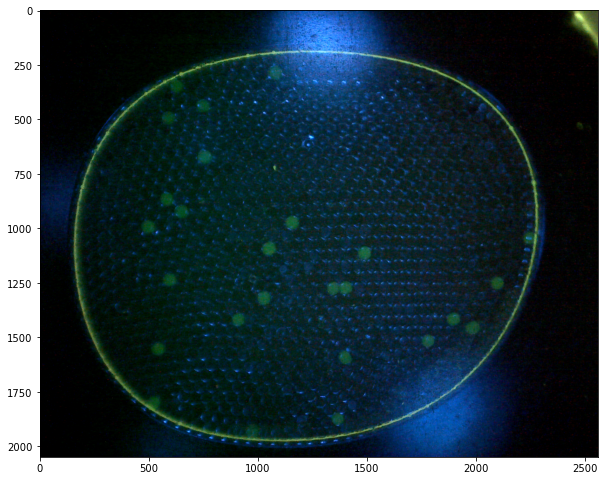

```python
# read color image
img_bgr = cv.imread("data/25-miniM.tif")

# reverse channels from CV's bgr to Matplotlib's rgb
img = img_bgr[:,:,[2,1,0]]
fig, ax = plt.subplots(1, 1, figsize=(10,10))
ax.imshow(img)
```

### 10.10.1.3 Channels and Histograms

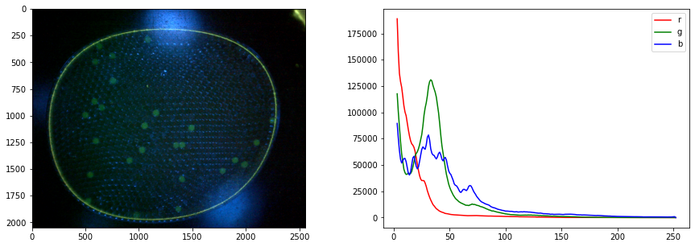

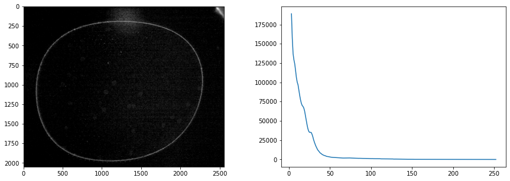

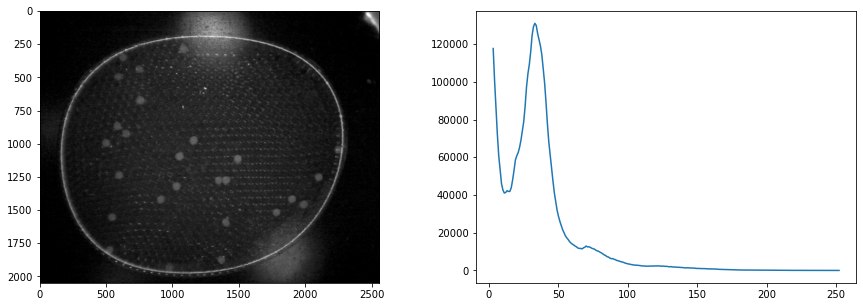

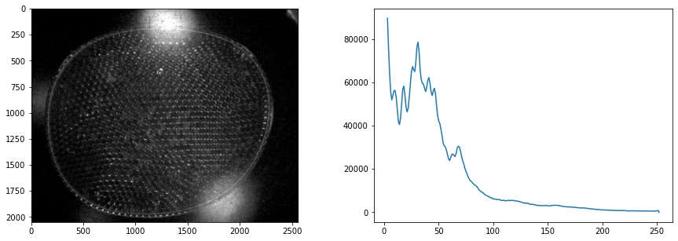

```python
def histogram(c, bp=3, wp=252):
    """Return histogram and bins for a single channel."""
    hist = cv.calcHist([c], [0], None, [wp-bp+1], [bp, wp])
    bins = [b for b in range(bp, wp+1)]
    return hist, bins

def display_channel(c):
    fig, ax = plt.subplots(1, 2, figsize=(15, 5))
    ax[0].imshow(c.astype(np.uint8), cmap="gray")
    hist, bins = histogram(c.astype(np.uint8))
    ax[1].plot(bins, hist)

hist = [histogram(c) for c in split(img)]

fig, ax = plt.subplots(1, 2, figsize=(15, 5))
ax[0].imshow(img)
for i,c in enumerate(['r','g','b']):
    ax[1].plot(hist[i][1], hist[i][0], c=c, label=c)
ax[1].legend()

r, g, b = cv.split(img)
display_channel(r)
display_channel(g)
display_channel(b)
```

### 10.10.1.4 Cross-Channel Interference

What we see above is that the blue leds used to excite the flourophores have a large enough spectrum to bleed over into the green channel. It would be best if this could be corrected in the experiment, perhaps by positioning a bandpass filter in front of the leds.

What we will attempt here is subtract a multiple of blue channel from the green channel, followed by exposure adjustments. The goal is to provide a cleaner image for doing particle labeling and counting.

By trial and error, we find a weighted difference of the green and blue channels, and a rescaling of the tone curve that retains the particles and reduces background interference.

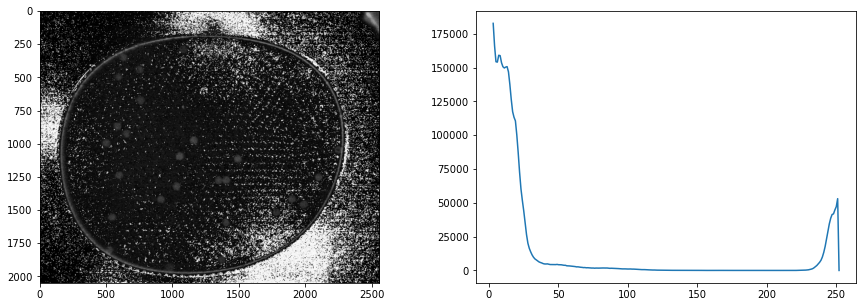

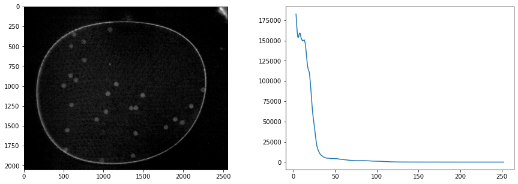

```python
# subtract blue channel from green channel
pimg = (g - 0.53*b)
display_channel(pimg)

# set zero threshold
pimg = np.where(pimg < 0, 0, pimg).astype(np.uint8)
display_channel(pimg)
```

### 10.10.1.5 Thresholding and Segmentation

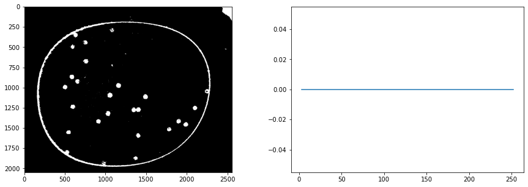

```python
# threshold
blurred = cv.medianBlur(pimg, 5)
T, qimg = cv.threshold(blurred, 0, 255, cv.THRESH_OTSU)
display_channel(qimg)
```

### 10.10.1.6 Labeling Objects

http://pageperso.lif.univ-mrs.fr/~francois.denis/IAAM1/scipy-html-1.0.0/tutorial/ndimage.html

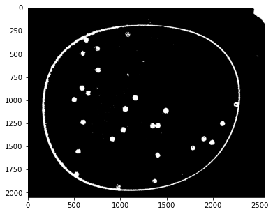

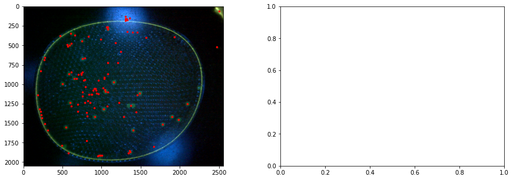

```python
# find particles and plot objects
fig, ax = plt.subplots(1, 1, figsize=(8, 5))
label_img, particle_count = ndimage.measurements.label(qimg, structure=np.ones((3,3)))
ax.imshow(np.where(label_img > 0, 1, np.zeros(pimg.shape)), cmap="gray")

# centers of mass
fig, ax = plt.subplots(1, 2, figsize=(15, 5))
pts = ndimage.center_of_mass(qimg, label_img, np.arange(1, particle_count + 1))
ax[0].imshow(img)
x = [x for (y,x) in pts]
y = [y for (y,x) in pts]
ax[0].plot(x, y, '.', ms=5, color='r')
```

### 10.10.1.7 Finding and Displaying Particles

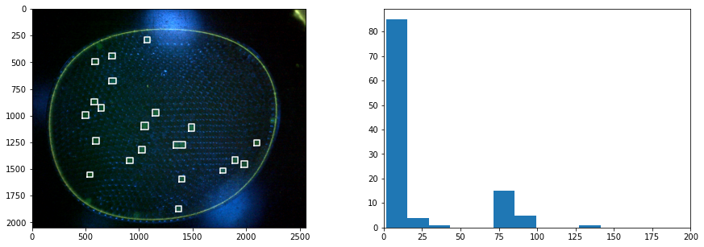

```python
# find the objects and place bounding boxes

fig, ax = plt.subplots(1, 2, figsize=(15, 5))
slices = ndimage.find_objects(label_img)
sizes = [np.sqrt((b.stop-b.start)**2 + (a.stop-a.start)**2) for a,b in slices]
ax[1].hist(sizes, bins=200)
ax[1].set_xlim(0, 200)
ax[0].imshow(img)
for k,size in enumerate(sizes):
    if size > 50 and size < 200:
        a,b = slices[k]
        ya = a.start
        yb = a.stop
        xa = b.start
        xb = b.stop
        ax[0].plot([xa, xb, xb, xa, xa], [yb, yb, ya, ya, yb], 'w')
```

## 10.10.2 Particle Labeling Class

```python
class LabelParticles():
    pass
```

< [10.0 Projects](https://jckantor.github.io/cbe61622/10.00-Projects.html) | Contents | [A.0 Python Source Library](https://jckantor.github.io/cbe61622/A.00-Appendices.html) >